# Influência da APP na produção de madeira na floresta Amazônica

Leonardo C. Peres

2023-05-12

# Apresentação

Neste projeto o objetivo foi utilizar a linguagem *R* para análisar a influência da presença de APP na produção em m³ de madeira e da quantidade de indivíduos presentes em diferêntes Unidades de Trabalho (UT) de manejo florestal realizado na floresta Amazônica.

# Hipotese

# Etapas

Para realização do projeto o mesmo foi dividido em três etapas:

- **Análise exploratória** Estudo dos dados e possibilidades de trabalhos
- **Modelagem** Análise estatísticas para responder a hipótese
- **Rmarkdow** Apresentação do projeto e dos códigos utilizados nas etapas anteriores

# Dados

Os dados utilizados são fornecidos pelo projeto **Floresta*R*** disponibilizados em um diretório publico do `GitHub`

O projeto **Floresta*R*** reúne professores, estudantes e profissionais dedicados à redação da série **Floresta*R*** de livros sobre o uso do *R* como ferramenta de análise de dados florestais.

Para mais informações a respeito do projeto acesse: github.com/LuizEstraviz/FlorestaR_dados

# 1. Exploratória

Nesta etapa do projeto, o objetivo foi verificar qual a relação existente entre a presença de APP na UT e a produção madeireira assim como o número de indivíduos presente.

## Abrindo os dados

```r
remove(list=ls())

#Definindo o diretório onde os arquivos estão armazenados
gitOnde <- "https://github.com/FlorestaR/dados/blob/main/1_AMAZON"
gitNome <- "shapes.zip"
gitArqv <- file.path(gitOnde, gitNome) %>% paste0("?raw=true")

#Criando diretório temporário e descompactando pasta zipada
tmpd <- tempdir(check = TRUE)                  # diretório temporário
zipf <- file.path(tmpd, "shapes.zip")            # arquivo temporário

if(!file.exists(zipf))      # garante download de dados binários (wb)
  download.file(gitArqv, mode="wb", destfile = zipf)

unzip(zipf, exdir = tmpd)   # shape é unziped no diretório temporário
unlink(zipf)                                # deleta o arquivo zipado

# leitura das camadas
dadosArv <- paste0(tmpd, "/shapes/Arvores.shp")     %>% read_sf()
dadosUts <- paste0(tmpd, "/shapes/UTs.shp")         %>% read_sf()
dadosApp <- paste0(tmpd, "/shapes/APP.shp")         %>% read_sf()
```

## Criando o `dataFrame` com os valores de volume e número de indivíduos por UT

```r
#filtrando meus registros
registros <- dadosArv %>%
  filter(destino == "PAB" | destino =="CF") %>%
  select(codARV,altura,dap,volume,codUT)

# Criar um dataframe com todas as codUT
todos_codUTs <- data.frame(unique(dadosUts$UT))
colnames(todos_codUTs) <- c("codUT")

#Gerando a média, a soma dos volumes e nº de espécies por UT
mediaVolUts <- merge(todos_codUTs, aggregate(ifelse(is.na(volume), 0, volume) ~ codUT,
  data = registros, mean), by = "codUT", all.x = TRUE)#media
somaVolUts <- merge(todos_codUTs, aggregate(ifelse(is.na(volume), 0, volume) ~ codUT,
  data = registros, sum), by = "codUT", all.x = TRUE)#Soma
contagemVolUts <- merge(todos_codUTs, aggregate(ifelse(is.na(volume), 0, volume) ~ codUT,
  data = registros, FUN = length), by = "codUT", all.x = TRUE)#Qtd

#Unindo todos os valores em um dataframe apenas e renomenado as colunas
resumoUts <- merge(merge(mediaVolUts, somaVolUts, by = "codUT"), contagemVolUts, by =
  "codUT")
colnames(resumoUts) <- c("codUT", "mediaVolume", "somaVolume", "numeroIndividuos")
resumoUts[is.na(resumoUts)] <- 0
```

## Calculando a área de APP existente dentro de cada UT

```r
# Dividir o shp dadosAPP em feições por Uts -> APP por Uts
poligono_recortado <- st_intersection(dadosApp, dadosUts)
appUts <- st_cast(poligono_recortado, "MULTIPOLYGON")

#Calcular a área da app nas Uts
area <- round(st_area(appUts)/10000,3)

#Removendo a unidade de medida do texto e transformando em número
appUts$AreaAPP <- as.numeric(gsub("[m^]", "", as.character(area)))

#Agrupando os valores de área da app pelas Uts e renomenado as colunas
areaAppUts <- aggregate(AreaAPP ~ UT, data = appUts, sum)
colnames(areaAppUts) <- c("codUT", "areaAPP")

#Enviando os dados da tabela areaAppUts para o shp resumoUts através d ID
resumoUts <- merge(resumoUts, areaAppUts, by = "codUT")

#Inserindo o valor bruto de área das Uts
resumoUts$area <- 100.00

#calculando a coluna de área liquida area com app - area da app
resumoUts$areaSApp <- resumoUts$area - resumoUts$areaAPP

#Selecionando apenas as colunas que interessa
resumoUts <- resumoUts %>%
  select(codUT,mediaVolume,somaVolume,numeroIndividuos,areaAPP,area,areaSApp)

#Criando as colunas com as informações de volume/ha e individuos/ha
resumoUts$volumeHectare <- resumoUts$somaVolume / resumoUts$areaSApp
resumoUts$individuosHectare <- resumoUts$numeroIndividuos / resumoUts$areaSApp

head(resumoUts)
```

```
##   codUT mediaVolume somaVolume numeroIndividuos areaAPP area areaSApp
## 1     1    2.964085    4209.00             1420   5.054  100   94.946
## 2     2    3.141168    3926.46             1250  12.115  100   87.885
## 3     3    2.974856    3308.04             1112  18.005  100   81.995
## 4     4    2.965656    3502.44             1181  10.937  100   89.063
## 5     5    3.065453    3316.82             1082  11.044  100   88.956
## 6     6    3.164379    3237.16             1023  27.144  100   72.856
##   volumeHectare individuosHectare
## 1      44.33046          14.95587
## 2      44.67725          14.22313
## 3      40.34441          13.56180
## 4      39.32542          13.26028
## 5      37.28607          12.16332
## 6      44.43230          14.04140
```

## Criação e plotagem dos gráficos de dispersão

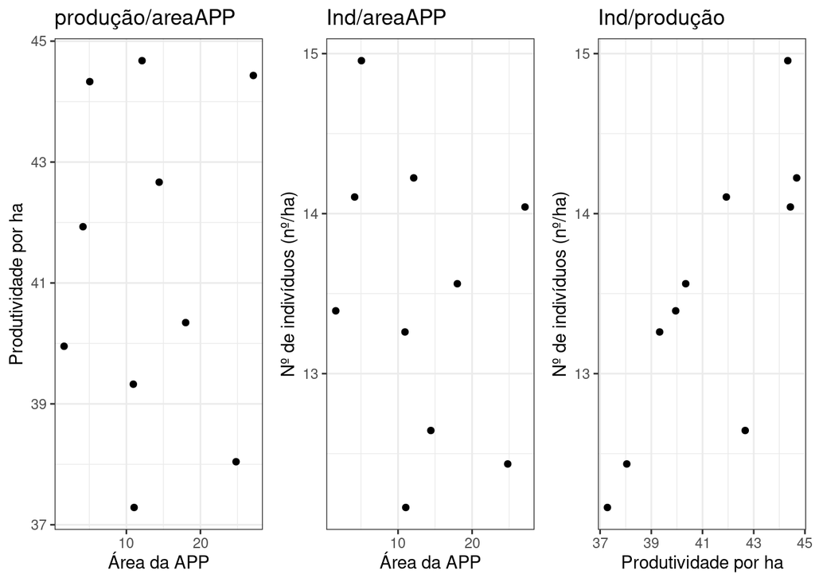

```r
GraficoVolume<-ggplot()+
  ggtitle("produção/areaAPP")+
  geom_point(data = resumoUts,
             aes(x= areaAPP, y = volumeHectare))+
  theme_bw()+
  xlab("Área da APP") + ylab("Produtividade por ha")

GraficoIndividuos<-ggplot()+
  ggtitle("Ind/areaAPP")+
  geom_point(data = resumoUts,
             aes(x= areaAPP, y = individuosHectare))+
  theme_bw()+
  xlab("Área da APP") + ylab("Nº de indivíduos (nº/ha)")

GraficoIndVol<-ggplot()+
  ggtitle("Ind/produção")+
  geom_point(data = resumoUts,
             aes(x= volumeHectare, y = individuosHectare))+
  theme_bw()+
  xlab("Produtividade por ha") + ylab("Nº de indivíduos (nº/ha)")

grid.arrange(GraficoVolume, GraficoIndividuos,GraficoIndVol, ncol = 3,nrow = 1)
```

Ao analisar os gráficos percebe-se que não existe relação entre os agentes avaliados (APP X Produção) e (APP X N° de indivíduos). Sendo assim foram gerados dois mapas para entender melhor sobre a dinâmica dos parâmetros avaliados e sua UT correspondente

## Mapas de localização dos blocos e seus respectivos valores de volume m³ por ha e quantidade de indivíduos

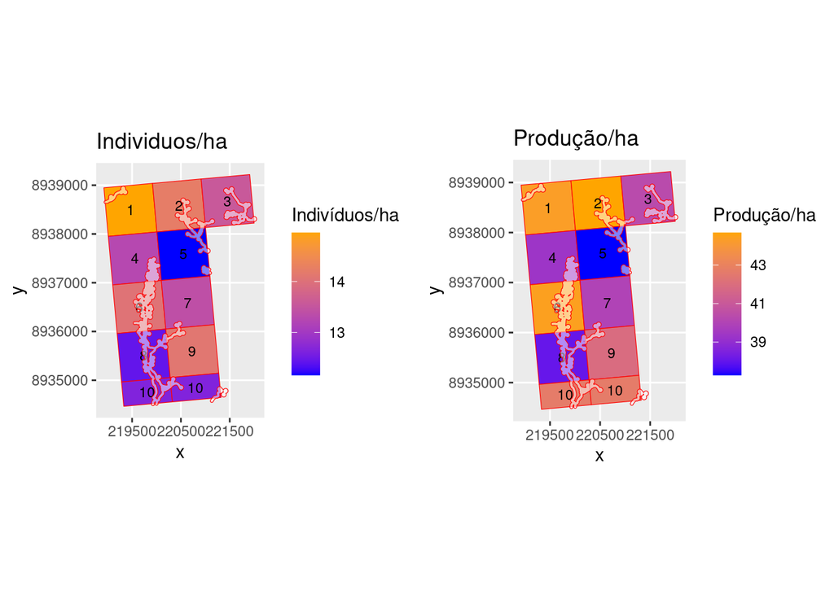

```r
colnames(resumoUts) <- c("UT", "mediaVolume", "somaVolume", "numeroIndividuos",
  "areaAPP", "area", "areaSApp", "volumeHectare", "individuosHectare")

dadosUts <- merge(dadosUts, resumoUts, by = "UT")

MapaVolUt <- ggplot() +
  ggtitle("Produção/ha")+
  geom_sf(data = dadosUts, aes(fill = volumeHectare), colour = "red") +
  scale_fill_gradient(low = "blue", high = "orange") +
  geom_sf_text(data = dadosUts, aes(label = UT), size = 3) +
  geom_sf(data = dadosApp, colour = "red", fill='white', alpha = 0.5) +
  coord_sf(datum=st_crs(29190)) +     # Especifica sistema de coord.
  scale_x_continuous(breaks = seq(from = 218500, to = 223000, by = 1000))+
  labs(fill = "Produção/ha")

MapaIndlUt <- ggplot() +
  ggtitle("Individuos/ha")+
  geom_sf(data = dadosUts, aes(fill = individuosHectare), colour = "red") +
  scale_fill_gradient(low = "blue", high = "orange",) +
  geom_sf_text(data = dadosUts, aes(label = UT), size = 3) +
  geom_sf(data = dadosApp, colour = "red", fill='white', alpha = 0.5) +
  coord_sf(datum=st_crs(29190)) +     # Especifica sistema de coord.
  scale_x_continuous(breaks = seq(from = 218500, to = 223000, by = 1000))+
  labs(fill = "Indivíduos/ha")

grid.arrange(MapaIndlUt, MapaVolUt, ncol = 2,nrow = 1)
```

# 2. Modelagem

Diante dos resultados obtidos durante a etapa exploratória dos dados, optou-se por agrupar as UTs em 3 classes diferentes de acordo com a área de APP dentro de cada uma delas. Foram consideradas UTs com alta influência de APP aquelas que apresentaram área de APP maior que 15 hectares, média influência aquelas que a área da APP se encontrasse entre 7 e 15 hectares e as demais foram consideradas com baixa influência.

## Criação da coluna categorizando as UTs de acordo com a área de APP dentro delas

```r
# Criar a nova coluna com base na condição
dadosUts$catAreaApp <- ifelse(dadosUts$areaAPP > 15, 2, ifelse(dadosUts$areaAPP > 7, 1,
  0))

print(dadosUts)
```

```
## Simple feature collection with 11 features and 14 fields
## Geometry type: POLYGON
## Dimension:     XY
## Bounding box:  xmin: 218921.9 ymin: 8934466 xmax: 222000.2 ymax: 8939219
## Projected CRS: SAD69 / UTM zone 20S
## First 10 features:
##    UT Y_INDEX X_INDEX      Area  Hectares mediaVolume somaVolume
## 1   1       1       8 1000000.0 100.00000    2.964085    4209.00
## 2   2       1       9 1000000.0 100.00000    3.141168    3926.46
## 3   3       1      10 1000000.0 100.00000    2.974856    3308.04
## 4   4       2       8 1000000.0 100.00000    2.965656    3502.44
## 5   5       2       9 1000000.0 100.00000    3.065453    3316.82
## 6   6       3       8 1000000.0 100.00000    3.164379    3237.16
## 7   7       3       9 1000000.0 100.00000    2.983255    3931.93
## 8   8       4       8 1000000.0 100.00000    3.059262    2860.41
```

[output cut: 24 more lines]

## Geração do mapa com as UTs classificadas

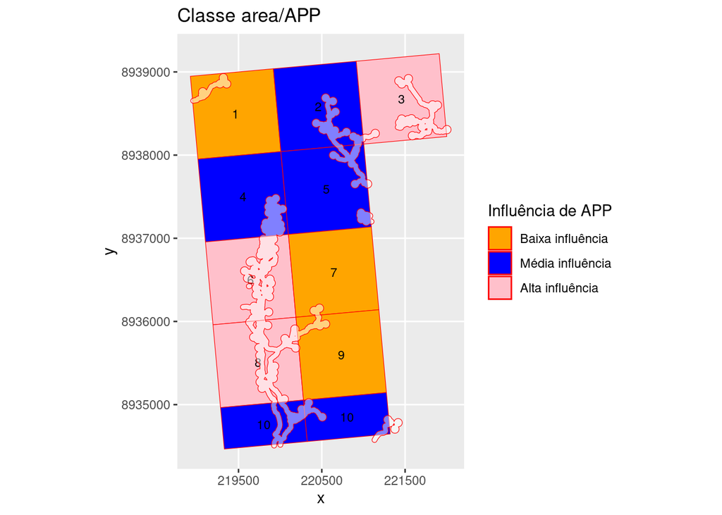

```r
# Converter a variável catAreaApp para o tipo de dados factor
dadosUts$catAreaApp <- factor(dadosUts$catAreaApp)

# Definir cores para cada valor da variável catAreaApp
cores <- c("orange", "blue", "pink")
nomes_cores <- setNames(cores, levels(dadosUts$catAreaApp))

# Plotar o gráfico com cores por valor
MapaClasseAPP <- ggplot() +
  ggtitle("Classe area/APP") +
  geom_sf(data = dadosUts, aes(fill = catAreaApp), colour = "red") +
  geom_sf_text(data = dadosUts, aes(label = UT), size = 3) +
  geom_sf(data = dadosApp, colour = "red", fill = 'white', alpha = 0.5) +
  coord_sf(datum = st_crs(29190)) +  # Especifica sistema de coord.
  scale_x_continuous(breaks = seq(from = 218500, to = 223000, by = 1000)) +
  scale_fill_manual(values = nomes_cores, labels = c("Baixa influência",
    "Média influência", "Alta influência")) +
  labs(fill = "Influência de APP")  # Altera o título da legenda

# Visualizar o gráfico
print(MapaClasseAPP)
```

## ANOVA

### ANOVA Volume

```r
modeloAnovaVol <- aov(mediaVolume ~ catAreaApp, data = dadosUts)

# Resumir os resultados da ANOVA
resultadoAnovaVol <- summary(modeloAnovaVol)

resultadoVolTexto <- capture.output(print(resultadoAnovaVol))

# Visualizar o resultado
print(resultadoVolTexto)
```

```
## [1] "            Df Sum Sq Mean Sq F value Pr(>F)"
## [2] "catAreaApp   2 0.0866 0.04330   2.246  0.168"
## [3] "Residuals    8 0.1542 0.01928               "
```

### ANOVA nº indivíduos

```r
modeloAnovaInd <- aov(individuosHectare ~ catAreaApp, data = dadosUts)

# Resumir os resultados da ANOVA
resultadoAnovaInd <- summary(modeloAnovaInd)

resultadoIndTexto <- capture.output(print(resultadoAnovaInd))

# Visualizar o resultado
print(resultadoIndTexto)
```

```
## [1] "            Df Sum Sq Mean Sq F value Pr(>F)"
## [2] "catAreaApp   2  2.551  1.2757   2.001  0.197"
## [3] "Residuals    8  5.101  0.6376               "
```

Ambas as ANOVAS indicam que os dois parâmetros testados não apresentam diferencia significativa entre eles e a presença de APP nas UTs, pois o Pr(>f) possuem valores maiores que 0,05.

# 3. Conclusão

De acordo com os resultados apresentados neste trabalho, a presença da APP nas unidades de trabalhos não são suficientes para gerarem alguma influência sobre a produção de madeira e a quantidade de indivíduos presentes, em um contexto geral considerando todos os indivíduos com DAP maior que 40.

Uma possibilidade seria replicar a mesma sequência lógica que gerou este resultado, porém filtrando o data-frame por espécies, com o objetivo de localizar espécies com maior aptidão a regiões próximas a APPs e outras com menor.

**RStudioCloud -** [PRODAPPMANJ](https://posit.cloud/content/5925743)